# Interaction with time

A. Abdias Baldiviezo

June 27, 2020

```r
# Use this R-Chunk to import all your datasets!
tickers_today <- c("CXW", "F", "GM", "JCP", "KR", "WDC", "NKE","T", "WDAY", "WFC", "WMT")
multpl_stocks <- tq_get(tickers_today, from = "2015-06-01", to = "2020-06-01", get = "stock.prices")
```

## Background

Your friend is going to give you his tickers at the beginning of your half-hour meeting with him (he is a busy friend). You will need to build an .Rmd file that will build a suite of visualizations rapidly for your conversation. You will need a series of stock performance graphics using library(dygraphs) and library(ggplot2). In real life, you might use one or the other, but this task is built to help you move from ts and xts to tidy objects for visualization.

## Data Wrangling

```r
# Use this R-Chunk to clean & wrangle your data!
filtered_multpl_stocks <- multpl_stocks %>% select(symbol, date, adjusted) %>% pivot_wider(names_from = symbol, values_from = adjusted)
```

## Data Visualization

### 5 year Timeline

Adjusted value shown for each stock

```r
# Use this R-Chunk to plot & visualize your data!

stocks <- cbind(filtered_multpl_stocks$CXW, filtered_multpl_stocks$F, filtered_multpl_stocks$GM, filtered_multpl_stocks$JCP, filtered_multpl_stocks$KR, filtered_multpl_stocks$WDC, filtered_multpl_stocks$NKE, filtered_multpl_stocks$T, filtered_multpl_stocks$WDAY, filtered_multpl_stocks$WFC, filtered_multpl_stocks$WMT, as.xts(filtered_multpl_stocks$date))

dygraph(stocks, main = "Multiple stocks from 06/2015-06/2020", ylab = "adjusted stock price") %>% dySeries("filtered_multpl_stocks.CXW", label = "CXW") %>%
  dySeries("filtered_multpl_stocks.F", label = "F") %>%
  dySeries("filtered_multpl_stocks.GM", label = "GM") %>%
  dySeries("filtered_multpl_stocks.JCP", label = "JCP") %>%
  dySeries("filtered_multpl_stocks.KR", label = "KR") %>%
  dySeries("filtered_multpl_stocks.WDC", label = "WDC") %>%
  dySeries("filtered_multpl_stocks.NKE", label = "NKE") %>%
  dySeries("filtered_multpl_stocks.T", label = "T") %>%
  dySeries("filtered_multpl_stocks.WDAY", label = "WDAY") %>%
  dySeries("filtered_multpl_stocks.WFC", label = "WFC") %>%
  dySeries("filtered_multpl_stocks.WMT", label = "WMT") %>%
  dyLegend(width = 100, labelsDiv = "labels")
```

[interactive chart not shown]

### Volume

Trading volume is a measure of how much of a given financial asset has traded in a period of time. For stocks, volume is measured in the number of shares traded and, for futures and options, it is based on how many contracts have changed hands. source: https://www.investopedia.com/articles/technical/02/010702.asp

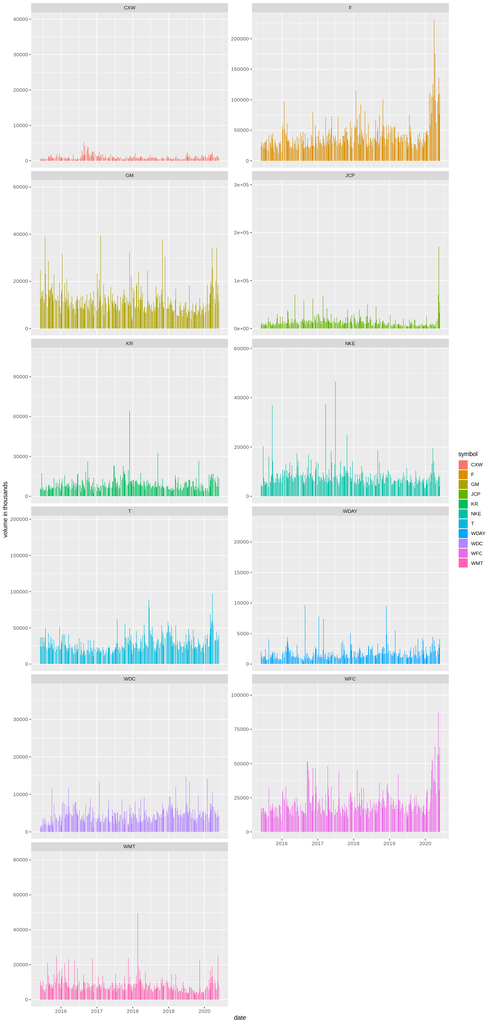

```r
ggplot(multpl_stocks, aes(date, volume/1000, fill = symbol)) + geom_histogram(stat = "identity") + facet_wrap(~symbol, scales = "free_y", nrow = 6) + labs(y="volume in thousands")
```

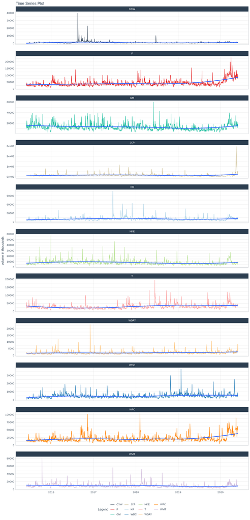

```r
multpl_stocks %>% plot_time_series(date, volume/1000, .color_var = symbol, .interactive = FALSE) + facet_wrap(~symbol, nrow = 11, scales = "free_y") + labs(y="volume in thousands")
```